# Análise Regressão Logística

### Base de dados: Mental Health and Technology Usage

#### Grupo: Marcos Rodrigues, Raphael Alcantara, Luis Felipe Nogeuira, Victor Nogueira

## Variáveis:

- User_ID: Código do respondente
- Age: Idade do respondente
- Gender: Genêro (Female, Male, Other)
- Tecnology_Usage_Hours: Uso de tecnologia diária em horas por dia
- Gaming_Hours: Tempo em horas de "gameplay" por dia
- Screen_Time_Hours: Tempo em horas de uso de tela por dia
- Mental_Health_Status: Status da saúde mental (Excellent, Good, Fair, Poor)
- Stress_Level: Nível de estresse (Medium, Low, High)
- Sleep_Hours: Tempo de sono em horas por dia
- Physical_Activity_Hours: Tempo de atividade física em horas por dia
- Support_Systems_Access: Se há acesso à sistemas de suporte (Yes, No)
- Work_Environment_Impact: Impacto envolvido no ambiente de trabalho (Negative, Neutral, Positive)
- Online_Support_Usage: Uso de suporte online (Yes, No

#### Esse conjunto de dados oferece insights sobre como o uso diário da tecnologia, incluindo mídias sociais e tempo de tela, afeta a saúde mental. Ele captura vários padrões comportamentais e suas correlações com indicadores de saúde mental, como níveis de estresse, qualidade do sono e produtividade.

Este trabalho tem como objetivo realizar uma análise abrangente sobre os dados relacionados à saúde mental e ao uso de tecnologias, com base na base de dados “Mental Health and Technology Usage 2024”. Inicialmente, será feita uma análise descritiva, a fim de explorar e resumir as principais características das variáveis envolvidas. Em seguida, será conduzida uma análise fatorial, com o intuito de identificar possíveis dimensões subjacentes aos dados, reduzindo a complexidade do conjunto de variáveis. Posteriormente, será aplicada uma análise de conglomerados (cluster analysis) para agrupar os indivíduos com base em suas semelhanças, permitindo identificar perfis distintos entre os participantes. Por fim, será desenvolvida uma regressão logística, com o objetivo de modelar a probabilidade de ocorrência de desfechos relacionados à saúde mental com base em variáveis explicativas selecionadas. Essas etapas permitirão uma compreensão mais profunda dos padrões e relações existentes na amostra analisada.

### Bibliotecas

```python
import pandas as pd
import matplotlib.pyplot as plt
from pandas import read_excel
import numpy as np
import seaborn as sns

from statsmodels.graphics.gofplots import qqplot

from scipy import stats as st

import researchpy as rs

from sklearn.preprocessing import StandardScaler

import locale

#locale.setlocale(locale.LC_ALL, '')
locale.setlocale(locale.LC_ALL, 'pt_BR.UTF-8')
pd.set_option('display.max_columns', None)
#pd.set_option('display.max_rows', None)
```

```python
# Base de dados
df = pd.read_csv('mental_health_and_technology_usage_2024.csv')
```

## Análise Descritiva

```python
df.head()
```

|  | User_ID | Age | Gender | Technology_Usage_Hours | Social_Media_Usage_Hours | Gaming_Hours | Screen_Time_Hours | Mental_Health_Status | Stress_Level | Sleep_Hours | Physical_Activity_Hours | Support_Systems_Access | Work_Environment_Impact | Online_Support_Usage |
| --- | --- | --- | --- | --- | --- | --- | --- | --- | --- | --- | --- | --- | --- | --- |
| 0 | USER-00001 | 23 | Female | 6.57 | 6.00 | 0.68 | 12.36 | Good | Low | 8.01 | 6.71 | No | Negative | Yes |
| 1 | USER-00002 | 21 | Male | 3.01 | 2.57 | 3.74 | 7.61 | Poor | High | 7.28 | 5.88 | Yes | Positive | No |
| 2 | USER-00003 | 51 | Male | 3.04 | 6.14 | 1.26 | 3.16 | Fair | High | 8.04 | 9.81 | No | Negative | No |
| 3 | USER-00004 | 25 | Female | 3.84 | 4.48 | 2.59 | 13.08 | Excellent | Medium | 5.62 | 5.28 | Yes | Negative | Yes |
| 4 | USER-00005 | 53 | Male | 1.20 | 0.56 | 0.29 | 12.63 | Good | Low | 5.55 | 4.00 | No | Positive | Yes |

```python
# Colunas
df.columns
```

```
Index(['User_ID', 'Age', 'Gender', 'Technology_Usage_Hours',
       'Social_Media_Usage_Hours', 'Gaming_Hours', 'Screen_Time_Hours',
       'Mental_Health_Status', 'Stress_Level', 'Sleep_Hours',
       'Physical_Activity_Hours', 'Support_Systems_Access',
       'Work_Environment_Impact', 'Online_Support_Usage'],
      dtype='object')
```

```python
# Dimensão
df.shape
```

```
(10000, 14)
```

```python
df.info()
```

```
<class 'pandas.core.frame.DataFrame'>
RangeIndex: 10000 entries, 0 to 9999
Data columns (total 14 columns):
 #   Column                    Non-Null Count  Dtype
---  ------                    --------------  -----
 0   User_ID                   10000 non-null  object
 1   Age                       10000 non-null  int64
 2   Gender                    10000 non-null  object
 3   Technology_Usage_Hours    10000 non-null  float64
 4   Social_Media_Usage_Hours  10000 non-null  float64
 5   Gaming_Hours              10000 non-null  float64
 6   Screen_Time_Hours         10000 non-null  float64
 7   Mental_Health_Status      10000 non-null  object
 8   Stress_Level              10000 non-null  object
 9   Sleep_Hours               10000 non-null  float64
 10  Physical_Activity_Hours   10000 non-null  float64
 11  Support_Systems_Access    10000 non-null  object
 12  Work_Environment_Impact   10000 non-null  object
 13  Online_Support_Usage      10000 non-null  object
dtypes: float64(6), int64(1), object(7)
memory usage: 1.1+ MB
```

```python
df.describe(include="all")
```

|  | User_ID | Age | Gender | Technology_Usage_Hours | Social_Media_Usage_Hours | Gaming_Hours | Screen_Time_Hours | Mental_Health_Status | Stress_Level | Sleep_Hours | Physical_Activity_Hours | Support_Systems_Access | Work_Environment_Impact | Online_Support_Usage |
| --- | --- | --- | --- | --- | --- | --- | --- | --- | --- | --- | --- | --- | --- | --- |
| count | 10000 | 10000.000000 | 10000 | 10000.000000 | 10000.000000 | 10000.000000 | 10000.000000 | 10000 | 10000 | 10000.000000 | 10000.000000 | 10000 | 10000 | 10000 |
| unique | 10000 | NaN | 3 | NaN | NaN | NaN | NaN | 4 | 3 | NaN | NaN | 2 | 3 | 2 |
| top | USER-00001 | NaN | Other | NaN | NaN | NaN | NaN | Excellent | Medium | NaN | NaN | No | Negative | No |
| freq | 1 | NaN | 3364 | NaN | NaN | NaN | NaN | 2518 | 3338 | NaN | NaN | 5006 | 3378 | 5013 |
| mean | NaN | 41.518600 | NaN | 6.474341 | 3.972321 | 2.515598 | 7.975765 | NaN | NaN | 6.500724 | 5.003860 | NaN | NaN | NaN |
| std | NaN | 13.920217 | NaN | 3.169022 | 2.313707 | 1.446748 | 4.042608 | NaN | NaN | 1.450933 | 2.905044 | NaN | NaN | NaN |
| min | NaN | 18.000000 | NaN | 1.000000 | 0.000000 | 0.000000 | 1.000000 | NaN | NaN | 4.000000 | 0.000000 | NaN | NaN | NaN |
| 25% | NaN | 29.000000 | NaN | 3.760000 | 1.980000 | 1.260000 | 4.520000 | NaN | NaN | 5.260000 | 2.490000 | NaN | NaN | NaN |
| 50% | NaN | 42.000000 | NaN | 6.425000 | 3.950000 | 2.520000 | 7.900000 | NaN | NaN | 6.500000 | 4.990000 | NaN | NaN | NaN |
| 75% | NaN | 54.000000 | NaN | 9.212500 | 5.990000 | 3.790000 | 11.500000 | NaN | NaN | 7.760000 | 7.540000 | NaN | NaN | NaN |
| max | NaN | 65.000000 | NaN | 12.000000 | 8.000000 | 5.000000 | 15.000000 | NaN | NaN | 9.000000 | 10.000000 | NaN | NaN | NaN |

### Contagem das variáveis categóricas

```python
# Contabilizando quantos cada atributo "gender" há
df.groupby('Gender').count()['Age'].apply("{0:,.0f}".format)
```

```
Gender
Female    3,286
Male      3,350
Other     3,364
Name: Age, dtype: object
```

```python
# Contabilizando quantos cada atributo "Mental_Health_Status" há
df.groupby('Mental_Health_Status').count()['Age'].apply("{0:,.0f}".format)
```

```
Mental_Health_Status
Excellent    2,518
Fair         2,490
Good         2,508
Poor         2,484
Name: Age, dtype: object
```

### Relação entre "Screen_Time_Hours" e "Stress_Level"

```python
# Criar as categorias para Screen_Time_Hours
bins = [0, 3, 6, 9, float('inf')]  # Faixas de tempo de tela
labels = ["< 3h", "3-6h", "6-9h", "> 9h"]  # Nomes das faixas
df['Screen_Time_Category'] = pd.cut(df['Screen_Time_Hours'], bins=bins, labels=labels, right=False)

# Contar quantas pessoas em cada categoria de tela possuem cada nível de estresse
stress_counts = df.groupby(['Screen_Time_Category', 'Stress_Level'], observed = False).size().reset_index(name='Count')
```

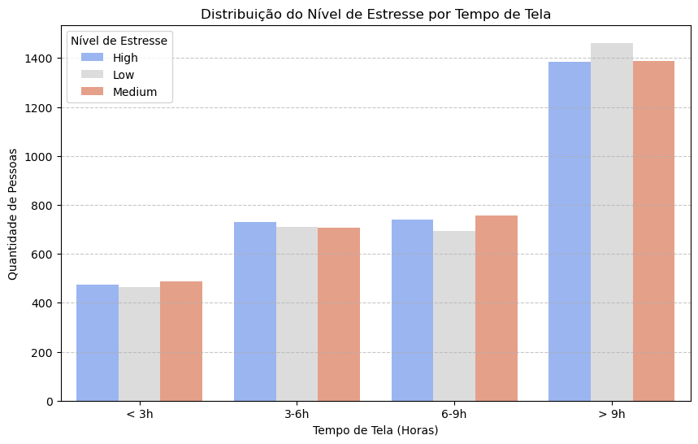

```python
# Criar o gráfico de barras
plt.figure(figsize=(10, 6))
sns.barplot(data=stress_counts, x='Screen_Time_Category', y='Count', hue='Stress_Level', palette='coolwarm')

# Configurações do gráfico
plt.title("Distribuição do Nível de Estresse por Tempo de Tela")
plt.xlabel("Tempo de Tela (Horas)")
plt.ylabel("Quantidade de Pessoas")
plt.legend(title="Nível de Estresse")
plt.grid(axis='y', linestyle='--', alpha=0.7)

# Exibir o gráfico
plt.show()
```

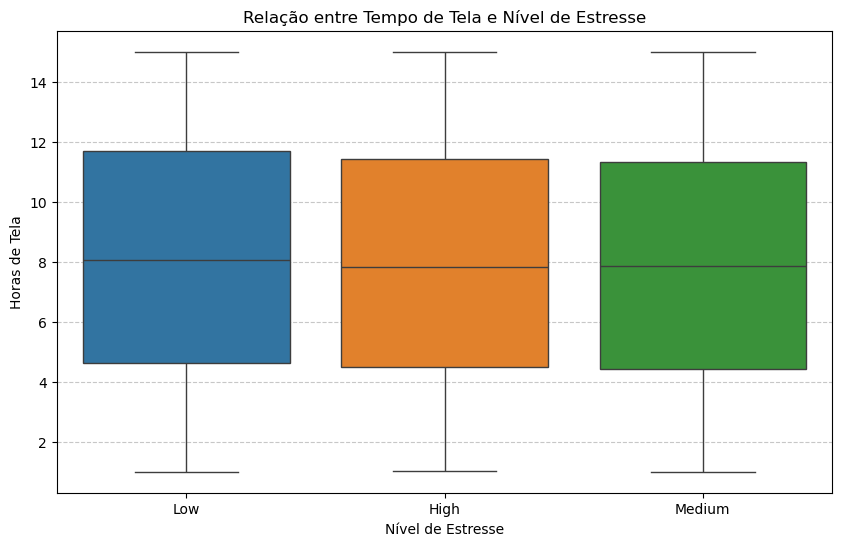

```python
# Criar o gráfico de caixa
plt.figure(figsize=(10, 6))
sns.boxplot(data=df, x='Stress_Level', y='Screen_Time_Hours', hue='Stress_Level')

# Configurações do gráfico
plt.title("Relação entre Tempo de Tela e Nível de Estresse")
plt.xlabel("Nível de Estresse")
plt.ylabel("Horas de Tela")
plt.grid(axis='y', linestyle='--', alpha=0.7)

plt.show()
```

### Relação entre "Social_Media_Usage_Hours" e "Stress"

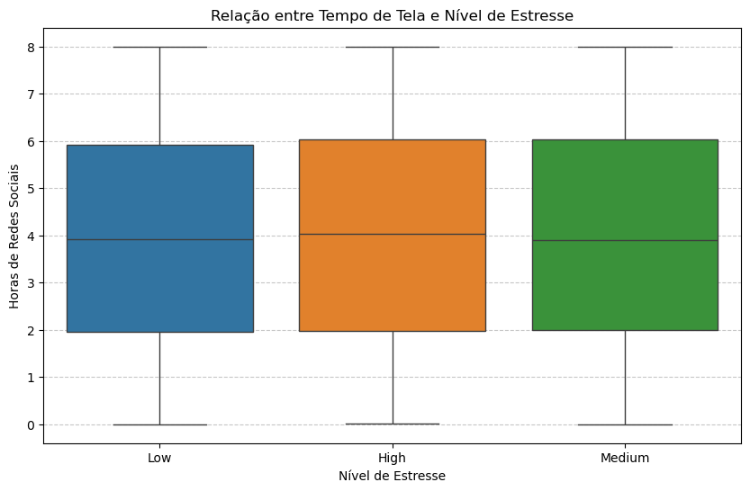

```python
# Criar o gráfico de caixa
plt.figure(figsize=(10, 6))
sns.boxplot(data=df, x='Stress_Level', y='Social_Media_Usage_Hours', hue='Stress_Level')

# Configurações do gráfico
plt.title("Relação entre Tempo de Tela e Nível de Estresse")
plt.xlabel("Nível de Estresse")
plt.ylabel("Horas de Redes Sociais")
plt.grid(axis='y', linestyle='--', alpha=0.7)

plt.show()
```

### Relação entre "Sleep_hours" e "Stress (High)"

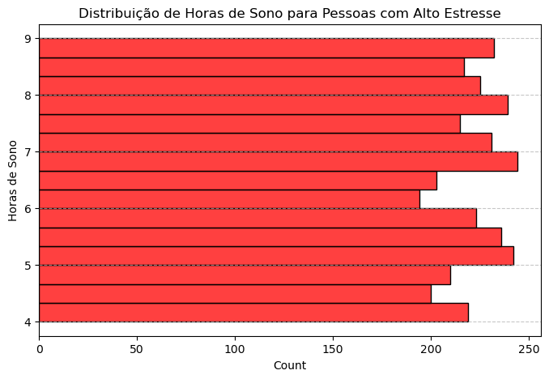

```python
# Filtrar os dados para quem tem nível de estresse "High"
df_stress = df[df['Stress_Level'] == 'High']

# Criar o gráfico de boxplot para mostrar a distribuição de horas de sono
plt.figure(figsize=(8, 5))
sns.histplot(data=df_stress, y='Sleep_Hours', color='red')

# Configurações do gráfico
plt.title("Distribuição de Horas de Sono para Pessoas com Alto Estresse")
plt.ylabel("Horas de Sono")
plt.grid(axis='y', linestyle='--', alpha=0.7)

# Exibir o gráfico
plt.show()
```

### Relação entre "Sleep_hours" e "Stress (Medium)"

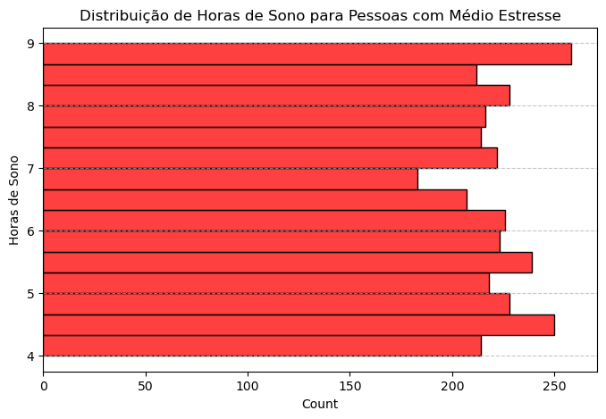

```python
# Filtrar os dados para quem tem nível de estresse "High"
df_stress = df[df['Stress_Level'] == 'Medium']

# Criar o gráfico de boxplot para mostrar a distribuição de horas de sono
plt.figure(figsize=(8, 5))
sns.histplot(data=df_stress, y='Sleep_Hours', color='red')

# Configurações do gráfico
plt.title("Distribuição de Horas de Sono para Pessoas com Médio Estresse")
plt.ylabel("Horas de Sono")
plt.grid(axis='y', linestyle='--', alpha=0.7)

# Exibir o gráfico
plt.show()
```

### Relação entre "Sleep_hours" e "Stress (Low)"

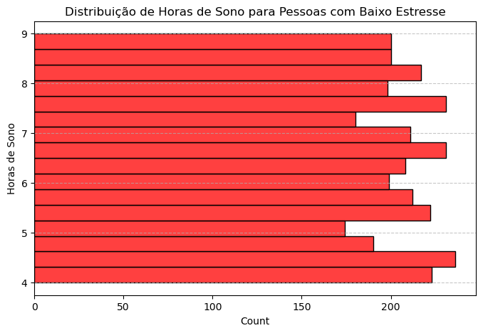

```python
# Filtrar os dados para quem tem nível de estresse "High"
df_stress = df[df['Stress_Level'] == 'Low']

# Criar o gráfico de boxplot para mostrar a distribuição de horas de sono
plt.figure(figsize=(8, 5))
sns.histplot(data=df_stress, y='Sleep_Hours', color='red')

# Configurações do gráfico
plt.title("Distribuição de Horas de Sono para Pessoas com Baixo Estresse")
plt.ylabel("Horas de Sono")
plt.grid(axis='y', linestyle='--', alpha=0.7)

# Exibir o gráfico
plt.show()
```

### Relação entre "Physical_Activity_Hours" e "Stress_Level"

```python
# Criar as categorias para Physical_Activity_Hours
bins = [0, 1, 3, 6, float('inf')]  # Faixas de atividade física
labels = ["0-1h (Sedentário)", "1-3h (Leve)", "3-6h (Moderado)", "> 6h (Intenso)"]  # Nomes das faixas
df['Physical_Activity_Category'] = pd.cut(df['Physical_Activity_Hours'], bins=bins, labels=labels, right=False)

# Contar quantas pessoas em cada categoria de atividade física possuem cada nível de estresse
stress_counts = df.groupby(['Physical_Activity_Category', 'Stress_Level'], observed = False).size().reset_index(name='Count')
```

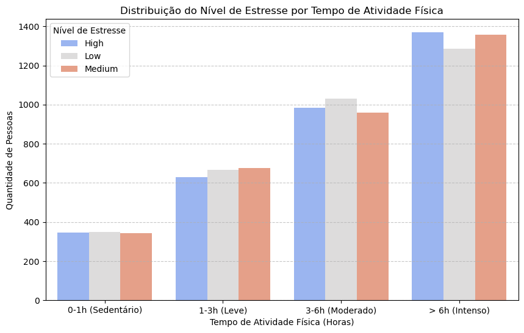

```python
# Criar o gráfico de barras
plt.figure(figsize=(10, 6))
sns.barplot(data=stress_counts, x='Physical_Activity_Category', y='Count', hue='Stress_Level', palette='coolwarm')

# Configurações do gráfico
plt.title("Distribuição do Nível de Estresse por Tempo de Atividade Física")
plt.xlabel("Tempo de Atividade Física (Horas)")
plt.ylabel("Quantidade de Pessoas")
plt.legend(title="Nível de Estresse")
plt.grid(axis='y', linestyle='--', alpha=0.7)

# Exibir o gráfico
plt.show()
```

```python
variaveis = ['Age', 'Technology_Usage_Hours', 'Social_Media_Usage_Hours', 'Gaming_Hours', 'Screen_Time_Hours', 'Sleep_Hours', 'Physical_Activity_Hours']
```

#### Média das variáveis

```python
df[variaveis].mean().apply("{0:,.2f}".format)
```

```
Age                         41.52
Technology_Usage_Hours       6.47
Social_Media_Usage_Hours     3.97
Gaming_Hours                 2.52
Screen_Time_Hours            7.98
Sleep_Hours                  6.50
Physical_Activity_Hours      5.00
dtype: object
```

#### Mediana das variáveis

```python
df[variaveis].median().apply("{0:,.2f}".format)
```

```
Age                         42.00
Technology_Usage_Hours       6.42
Social_Media_Usage_Hours     3.95
Gaming_Hours                 2.52
Screen_Time_Hours            7.90
Sleep_Hours                  6.50
Physical_Activity_Hours      4.99
dtype: object
```

#### Variância das variáveis

```python
df[variaveis].var().apply("{0:,.3f}".format)
```

```
Age                         193.772
Technology_Usage_Hours       10.043
Social_Media_Usage_Hours      5.353
Gaming_Hours                  2.093
Screen_Time_Hours            16.343
Sleep_Hours                   2.105
Physical_Activity_Hours       8.439
dtype: object
```

#### Desvio Padrão das variáveis

```python
df[variaveis].std().apply("{0:,.3f}".format)
```

```
Age                         13.920
Technology_Usage_Hours       3.169
Social_Media_Usage_Hours     2.314
Gaming_Hours                 1.447
Screen_Time_Hours            4.043
Sleep_Hours                  1.451
Physical_Activity_Hours      2.905
dtype: object
```

#### MAD das variáveis

```python
from scipy.stats import median_abs_deviation

df[variaveis].apply(median_abs_deviation).apply("{:,.2f}".format)
```

```
Age                         12.00
Technology_Usage_Hours       2.73
Social_Media_Usage_Hours     2.02
Gaming_Hours                 1.27
Screen_Time_Hours            3.50
Sleep_Hours                  1.25
Physical_Activity_Hours      2.53
dtype: object
```

#### Maiores valores

```python
df[variaveis].max().apply("{0:,.2f}".format)
```

```
Age                         65.00
Technology_Usage_Hours      12.00
Social_Media_Usage_Hours     8.00
Gaming_Hours                 5.00
Screen_Time_Hours           15.00
Sleep_Hours                  9.00
Physical_Activity_Hours     10.00
dtype: object
```

#### Menores valores

```python
df[variaveis].min().apply("{0:,.2f}".format)
```

```
Age                         18.00
Technology_Usage_Hours       1.00
Social_Media_Usage_Hours     0.00
Gaming_Hours                 0.00
Screen_Time_Hours            1.00
Sleep_Hours                  4.00
Physical_Activity_Hours      0.00
dtype: object
```

```python
df[variaveis].describe().round(2)
```

|  | Age | Technology_Usage_Hours | Social_Media_Usage_Hours | Gaming_Hours | Screen_Time_Hours | Sleep_Hours | Physical_Activity_Hours |
| --- | --- | --- | --- | --- | --- | --- | --- |
| count | 10000.00 | 10000.00 | 10000.00 | 10000.00 | 10000.00 | 10000.00 | 10000.00 |
| mean | 41.52 | 6.47 | 3.97 | 2.52 | 7.98 | 6.50 | 5.00 |
| std | 13.92 | 3.17 | 2.31 | 1.45 | 4.04 | 1.45 | 2.91 |
| min | 18.00 | 1.00 | 0.00 | 0.00 | 1.00 | 4.00 | 0.00 |
| 25% | 29.00 | 3.76 | 1.98 | 1.26 | 4.52 | 5.26 | 2.49 |
| 50% | 42.00 | 6.42 | 3.95 | 2.52 | 7.90 | 6.50 | 4.99 |
| 75% | 54.00 | 9.21 | 5.99 | 3.79 | 11.50 | 7.76 | 7.54 |
| max | 65.00 | 12.00 | 8.00 | 5.00 | 15.00 | 9.00 | 10.00 |

#### Assimetria dos dados

Majoritarimente assimétricas a direita, com uma assimétrica a esquerda (gaming hour)

```python
df[variaveis].skew().apply("{0:,.3f}".format)
```

```
Age                          0.005
Technology_Usage_Hours       0.018
Social_Media_Usage_Hours     0.011
Gaming_Hours                -0.024
Screen_Time_Hours            0.015
Sleep_Hours                  0.004
Physical_Activity_Hours      0.001
dtype: object
```

### Curtose dos dados

Todos negativos, temos uma pláticúrtica

```python
df[variaveis].kurt().apply("{:,.3f}".format)
```

```
Age                         -1.208
Technology_Usage_Hours      -1.191
Social_Media_Usage_Hours    -1.211
Gaming_Hours                -1.205
Screen_Time_Hours           -1.194
Sleep_Hours                 -1.212
Physical_Activity_Hours     -1.211
dtype: object
```

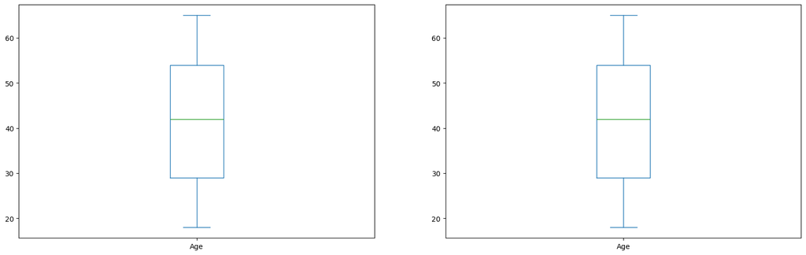

```python
plt.rcParams["figure.figsize"] = (20,6)
fig, axes = plt.subplots(1, 2)
df["Age"].plot(kind="box", ax=axes[0])
df["Age"].plot(kind="box", showfliers=False, ax=axes[1])
```

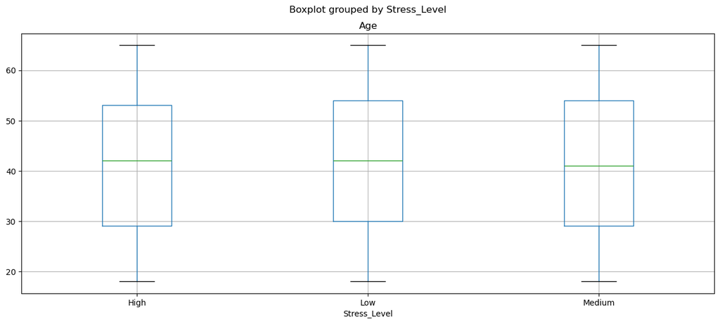

```python
boxplot = df.boxplot(column="Age", by='Stress_Level', layout=(1,1), figsize=[15,6], showfliers=False)
```

### Covariância

```python
df[variaveis].cov().round(0)
```

|  | Age | Technology_Usage_Hours | Social_Media_Usage_Hours | Gaming_Hours | Screen_Time_Hours | Sleep_Hours | Physical_Activity_Hours |
| --- | --- | --- | --- | --- | --- | --- | --- |
| Age | 194.0 | 1.0 | 0.0 | 0.0 | 0.0 | -0.0 | -0.0 |
| Technology_Usage_Hours | 1.0 | 10.0 | 0.0 | 0.0 | 0.0 | -0.0 | 0.0 |
| Social_Media_Usage_Hours | 0.0 | 0.0 | 5.0 | 0.0 | -0.0 | 0.0 | 0.0 |
| Gaming_Hours | 0.0 | 0.0 | 0.0 | 2.0 | -0.0 | 0.0 | -0.0 |
| Screen_Time_Hours | 0.0 | 0.0 | -0.0 | -0.0 | 16.0 | -0.0 | 0.0 |
| Sleep_Hours | -0.0 | -0.0 | 0.0 | 0.0 | -0.0 | 2.0 | -0.0 |
| Physical_Activity_Hours | -0.0 | 0.0 | 0.0 | -0.0 | 0.0 | -0.0 | 8.0 |

#### Correlação entre as variáveis

```python
df[variaveis].corr().round(4)
```

|  | Age | Technology_Usage_Hours | Social_Media_Usage_Hours | Gaming_Hours | Screen_Time_Hours | Sleep_Hours | Physical_Activity_Hours |
| --- | --- | --- | --- | --- | --- | --- | --- |
| Age | 1.0000 | 0.0175 | 0.0092 | 0.0052 | 0.0072 | -0.0015 | -0.0045 |
| Technology_Usage_Hours | 0.0175 | 1.0000 | 0.0232 | 0.0144 | 0.0079 | -0.0098 | 0.0102 |
| Social_Media_Usage_Hours | 0.0092 | 0.0232 | 1.0000 | 0.0058 | -0.0084 | 0.0044 | 0.0023 |
| Gaming_Hours | 0.0052 | 0.0144 | 0.0058 | 1.0000 | -0.0078 | 0.0104 | -0.0004 |
| Screen_Time_Hours | 0.0072 | 0.0079 | -0.0084 | -0.0078 | 1.0000 | -0.0112 | 0.0305 |
| Sleep_Hours | -0.0015 | -0.0098 | 0.0044 | 0.0104 | -0.0112 | 1.0000 | -0.0100 |
| Physical_Activity_Hours | -0.0045 | 0.0102 | 0.0023 | -0.0004 | 0.0305 | -0.0100 | 1.0000 |

### Conclusão:

Inicialmente, fazendo a análise descritiva, os respondentes tem uma faixa de 18 a 65 anos com uma média de 41 anos de idade. Conseguimos perceber que num geral as pessoas usam muito mais telas, ou seja, uma média de screen time de 8 horas. Uma média de sono baixa do esperado de 6,5 horas diárias, 5 horas de exercícios físicos diários, porém com um grande desvio padrão oque nos mostra que existe pessoas bem ativas e pessoas pouco ativas. Mas num geral de informação, temos que as considerações são bem conservadoras, com dados pouco distribuídos entre eles.